# Arboles de clasificacion en R

### Relación entre el nivel de educación y si el cliente incurrirá en default payment

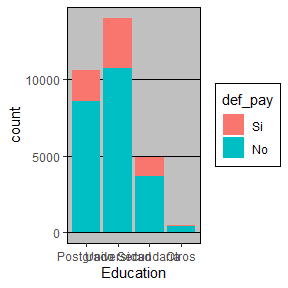

```r
ggplot(data_clean_f, aes(x = EDUCATION, fill = def_pay)) +
  geom_bar() +
  labs(x = 'Education') +
  theme_excel()
```

### Relación entre la edad y si el cliente incurrirá en default payment

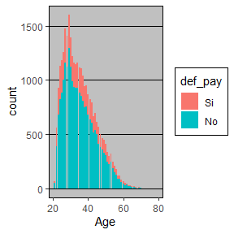

```r
ggplot(data_clean_f, aes(x = AGE, fill = def_pay)) +
  geom_bar() +
  labs(x = 'Age') +
  theme_excel()
```

### Relación entre sexo y si el cliente incurrirá en default payment

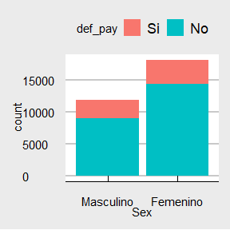

```r
ggplot(data_clean_f, aes(x = SEX, fill = def_pay)) +
  geom_bar() +
  labs(x = 'Sex') +
  theme_economist_white()
```

### Relación entre el estado civil y si el cliente incurrirá en default payment

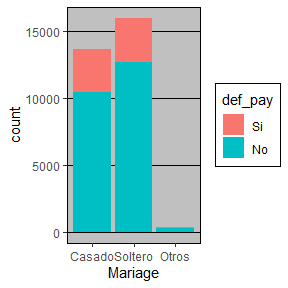

```r
ggplot(data_clean_f, aes(x = MARRIAGE, fill = def_pay)) +
  geom_bar() +
  labs(x = 'Mariage') +
  theme_excel()
```

### Relación entre la educación, edad y si el cliente incurrirá en def pay

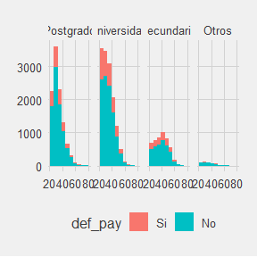

```r
ggplot(data_clean_f, aes(AGE, fill = def_pay)) +
  geom_histogram(binwidth = 6) +
  facet_grid(.~EDUCATION) +
  theme_fivethirtyeight()
```

### Mapa de correlación pago al corriente/atrasado

Es posible notar que existe una correlación alta entre un mes con su mes inmediato anterior.

AGO-JUL: 0.77

JUL-JUN: 0.78

JUN-MAY: 0.82

MAY-ABR: 0.82

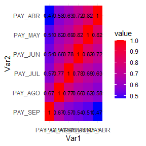

```r
pay_columns = c("PAY_SEP", "PAY_AGO", "PAY_JUL", "PAY_JUN", "PAY_MAY", "PAY_ABR")
dthm <- data_clean_f[pay_columns]

data_cor <- cor(dthm[sapply(dthm,is.numeric)])

data_melt <- melt(data_cor)

ggplot(data_melt, aes(x = Var1, y = Var2,
                      fill = value,
                      label = round(value,2)))+
                    geom_tile() +
                    geom_text(size = 3) +
                    scale_fill_gradient(low = "blue", high = "red") +
                    theme_minimal()
```

### Prueba de multicolinealidad

#### Construimos el modelo de regresión lineal

```r
# Dividir los datos en conjuntos de entrenamiento y prueba
set.seed(123) # Establecer una semilla para reproducir los resultados
entrenamiento_porcentaje <- 0.7 # Proporción de los datos que se utilizarán para entrenamiento
datos_entrenamiento_lm <- data_clean %>%
  group_by(def_pay) %>% # Agrupar por variable flag
  sample_frac(entrenamiento_porcentaje) # Muestra aleatoria una vez agrupado

datos_prueba_lm <- anti_join(data_clean, datos_entrenamiento_lm, by = c("ID"))
```

```r
#Construimos el modelo de Regresión
modelo_lm <- lm(def_pay ~., data = datos_entrenamiento_lm)

kable(coef(modelo_lm))
```

|  | x |
| --- | --- |
| (Intercept) | 0.3202442 |
| ID | -0.0000001 |
| LIMIT_BAL | -0.0000001 |
| SEX | -0.0144674 |
| EDUCATION | -0.0159634 |
| MARRIAGE | -0.0268837 |
| AGE | 0.0015186 |
| PAY_SEP | 0.0950322 |
| PAY_AGO | 0.0249250 |
| PAY_JUL | 0.0080723 |
| PAY_JUN | 0.0060466 |
| PAY_MAY | 0.0047204 |
| PAY_ABR | -0.0003114 |
| BILL_AMT_SEP | -0.0000006 |
| BILL_AMT_AGO | 0.0000001 |
| BILL_AMT_JUL | 0.0000000 |
| BILL_AMT_JUN | -0.0000001 |
| BILL_AMT_MAY | 0.0000000 |
| BILL_AMT_ABR | 0.0000001 |
| PAY_AMT_SEP | -0.0000005 |
| PAY_AMT_AGO | -0.0000003 |
| PAY_AMT_JUL | -0.0000001 |
| PAY_AMT_JUN | -0.0000001 |
| PAY_AMT_MAY | -0.0000004 |
| PAY_AMT_ABR | -0.0000001 |

```r
#Se hacen predicciones
predicciones <- modelo_lm %>% predict(datos_prueba_lm)
```

```r
#Revisamos el desempeño del modelo con RMSE de CARET

data.frame(RMSE=RMSE(predicciones, datos_prueba_lm$def_pay),R2=R2(predicciones,datos_prueba_lm$def_pay))
```

```
##        RMSE       R2
## 1 0.3897244 0.118762
```

```r
# Cómo vemos, el RMSE parece aceptable
```

#### Detectando multicolinealidad

Hay mucha bibliografía sobre el tema, sin embargo uno de los Paper más recientes “Johnston R, Jones K, Manley D. Confounding and collinearity in regression analysis: a cautionary tale and an alternative procedure, illustrated by studies of British voting behaviour.” indica que un VIF mayor o igual que 2.5 indica colinealidad considerable, por lo que se decide probar el modelo nuevamente sin las variables que tengan arriba de 3.

Tiene mucho sentido que no evaluemos el mes inmediato anterior para saber si sera def pay o no, porque practicamente nos estaría dando el resultado.

```r
kable(car::vif(modelo_lm))
```

|  | x |
| --- | --- |
| ID | 1.016360 |
| LIMIT_BAL | 1.548270 |
| SEX | 1.023576 |
| EDUCATION | 1.130246 |
| MARRIAGE | 1.220253 |
| AGE | 1.268433 |
| PAY_SEP | 1.904306 |
| PAY_AGO | 3.174717 |
| PAY_JUL | 3.675022 |
| PAY_JUN | 4.340212 |
| PAY_MAY | 4.746941 |
| PAY_ABR | 3.215054 |
| BILL_AMT_SEP | 13.933634 |
| BILL_AMT_AGO | 25.783615 |
| BILL_AMT_JUL | 22.250491 |
| BILL_AMT_JUN | 20.713161 |
| BILL_AMT_MAY | 25.390551 |
| BILL_AMT_ABR | 15.091258 |
| PAY_AMT_SEP | 1.821678 |
| PAY_AMT_AGO | 2.010658 |
| PAY_AMT_JUL | 1.817387 |
| PAY_AMT_JUN | 1.686329 |
| PAY_AMT_MAY | 1.654552 |
| PAY_AMT_ABR | 1.166661 |

```r
data_clean_multi <- select(data_clean, -BILL_AMT_SEP, -BILL_AMT_AGO, -BILL_AMT_JUL, -BILL_AMT_JUN, -BILL_AMT_MAY, -BILL_AMT_ABR, -PAY_AGO, -PAY_JUL, -PAY_JUN, -PAY_MAY, -PAY_ABR)
kable(colnames(data_clean_multi))
```

| x |
| --- |
| ID |
| LIMIT_BAL |
| SEX |
| EDUCATION |
| MARRIAGE |
| AGE |
| PAY_SEP |
| PAY_AMT_SEP |
| PAY_AMT_AGO |
| PAY_AMT_JUL |
| PAY_AMT_JUN |
| PAY_AMT_MAY |
| PAY_AMT_ABR |
| def_pay |

```r
entrenamiento_porcentaje <- 0.7 # Proporción de los datos que se utilizarán para entrenamiento
datos_entrenamiento_lm_multi <- data_clean_multi %>%
  group_by(def_pay) %>% # Agrupar por variable flag
  sample_frac(entrenamiento_porcentaje) # Muestra aleatoria una vez agrupado

datos_prueba_lm_multi <- anti_join(data_clean_multi, datos_entrenamiento_lm_multi, by = c("ID"))
```

```r
modelo_lm_new <- lm(def_pay ~., data = datos_entrenamiento_lm_multi)
kable(coef(modelo_lm_new))
```

|  | x |
| --- | --- |
| (Intercept) | 0.3338533 |
| ID | 0.0000000 |
| LIMIT_BAL | -0.0000002 |
| SEX | -0.0124787 |
| EDUCATION | -0.0145564 |
| MARRIAGE | -0.0364635 |
| AGE | 0.0011395 |
| PAY_SEP | 0.1129795 |
| PAY_AMT_SEP | -0.0000008 |
| PAY_AMT_AGO | -0.0000003 |
| PAY_AMT_JUL | -0.0000001 |
| PAY_AMT_JUN | -0.0000004 |
| PAY_AMT_MAY | -0.0000004 |
| PAY_AMT_ABR | -0.0000002 |

#### Podemos ver que nos da un RMSE similar quitando un montón de columnas:

```r
predicciones <-modelo_lm_new %>% predict(datos_prueba_lm_multi)
data.frame(RMSE=RMSE(predicciones, datos_prueba_lm_multi$def_pay),R2=R2(predicciones,datos_prueba_lm_multi$def_pay))
```

```
##        RMSE        R2
## 1 0.3914092 0.1109415
```

#### Y el modelo ya no presenta multicolinealidad:

```r
kable(car::vif(modelo_lm_new))
```

|  | x |
| --- | --- |
| ID | 1.004472 |
| LIMIT_BAL | 1.352992 |
| SEX | 1.020205 |
| EDUCATION | 1.129112 |
| MARRIAGE | 1.218575 |
| AGE | 1.266496 |
| PAY_SEP | 1.085051 |
| PAY_AMT_SEP | 1.138628 |
| PAY_AMT_AGO | 1.121627 |
| PAY_AMT_JUL | 1.107779 |
| PAY_AMT_JUN | 1.087441 |
| PAY_AMT_MAY | 1.097708 |
| PAY_AMT_ABR | 1.100514 |

## Drop columnas con multicolinealidad del DF clean

```r
data_clean_trees <- select(data_clean_f, -BILL_AMT_SEP, -BILL_AMT_AGO, -BILL_AMT_JUL, -BILL_AMT_JUN, -BILL_AMT_MAY, -BILL_AMT_ABR, -PAY_SEP )
kable(colnames(data_clean_trees))
```

| x |
| --- |
| ID |
| LIMIT_BAL |
| SEX |
| EDUCATION |
| MARRIAGE |
| AGE |
| PAY_AGO |
| PAY_JUL |
| PAY_JUN |
| PAY_MAY |
| PAY_ABR |
| PAY_AMT_SEP |
| PAY_AMT_AGO |
| PAY_AMT_JUL |
| PAY_AMT_JUN |
| PAY_AMT_MAY |
| PAY_AMT_ABR |
| def_pay |

# Partición de datos con conjunto de datos completo

```r
entrenamiento_porcentaje <- 0.7 # Proporción de los datos que se utilizarán para entrenamiento
datos_entrenamiento <- data_clean_trees %>%
  group_by(def_pay) %>% # Agrupar por variable flag
  sample_frac(entrenamiento_porcentaje) # Muestra aleatoria una vez agrupado

datos_prueba <- anti_join(data_clean, datos_entrenamiento, by = c("ID"))
```